# Simulating from a logisitic regression

AG Schissler

19 Apr 2018

# Introduction

## Why simulate to understand a model?

- To ensure you know exactly what your model assumed.
- To posit a generative model for your data.
- To check your code (implementation) via recovery of simulation settings.
- To see what good diagnostics look like.
- To see *poor* diagnostics to guide model adjustments (iterate model design).

## General principles

- Let your real data guide the simulation settings.
- e.g., select $n$ = number of observations
- e.g., select distributions for predictors, $Y$, with approximate shape, center, spread.
- Explore what happens as $n$ increases. Or you change models, transformations, etc.
- Experiment with your simulation to understand: Data Science!

# Simulating from logistic regression with a single Gaussian predictor

## A logistic model for a binary outcome

$log \left( \frac{\theta (x)}{1-\theta (x)} \right) = \beta_0 + \beta_1 x$ $\iff$ $\theta (x) = \frac{1}{1+exp(- \{\beta_0 + \beta_1 x\})}$

with $(Y|x_i) \sim Bin(m_i=1,\theta (x_i))$ for $i=1,...,n$.

## Data generation for a Gaussian predictor, same variance for each level of $Y$.

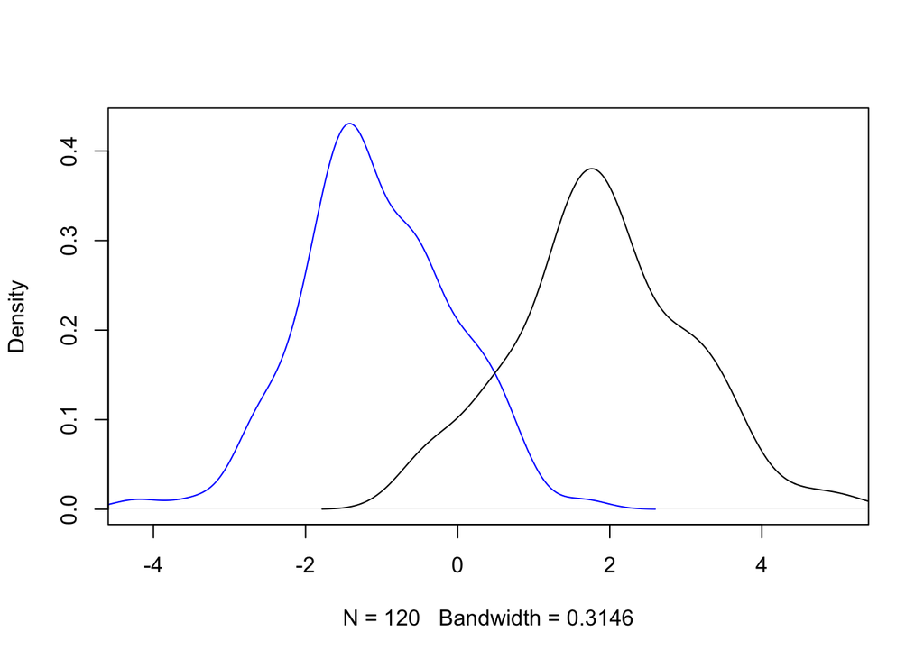

Estimated densities for the conditional distribution of X given each value of Y. The blue curve is X|Y=0 and the black curve is X|Y=1.

```r
set.seed(44)
n <- 200
theta_overall <- 0.4
## number of successes
num1 <- theta_overall*n
num0 <- n - num1
x1 <- rnorm(n = num1, mean = 2, sd = 1)
x0 <- rnorm(n = num0, mean = -1, sd = 1)
plot(density(x0), xlim=c(min(x0), max(x1)), main="", col = "blue")
lines(density(x1))
```

```r
x <- c( x1, x0 )
y <- c( rep(1, num1), rep(0, num0) )
m1 <- glm( y ~ x, family=binomial() )
summary(m1)
```

```
##
## Call:
## glm(formula = y ~ x, family = binomial())
##
## Deviance Residuals:
##     Min       1Q   Median       3Q      Max
## -2.4844  -0.2190  -0.0602   0.1674   2.4397
##
## Coefficients:
##             Estimate Std. Error z value Pr(>|z|)
## (Intercept)   -1.270      0.331   -3.84  0.00012
## x              2.607      0.405    6.44  1.2e-10
##
## (Dispersion parameter for binomial family taken to be 1)
##
##     Null deviance: 269.205  on 199  degrees of freedom
## Residual deviance:  78.489  on 198  degrees of freedom
## AIC: 82.49
##
## Number of Fisher Scoring iterations: 7
```

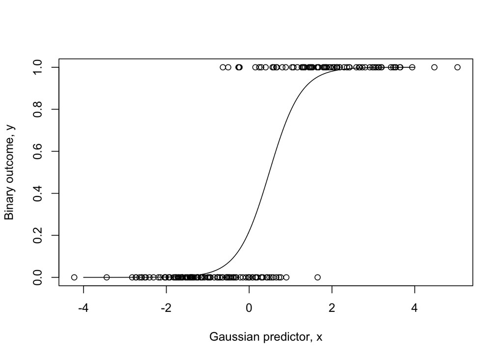

```r
plot(x, y,
     ylab="Binary outcome, y",
     xlab="Gaussian predictor, x")
x_seq <- seq(-4,4,length.out = n )
y_hat <- 1/(1+exp(-1*(m1$coeff[1] + m1$coeff[2]*x_seq)))
lines(x_seq,y_hat)
```

## Diagnostics

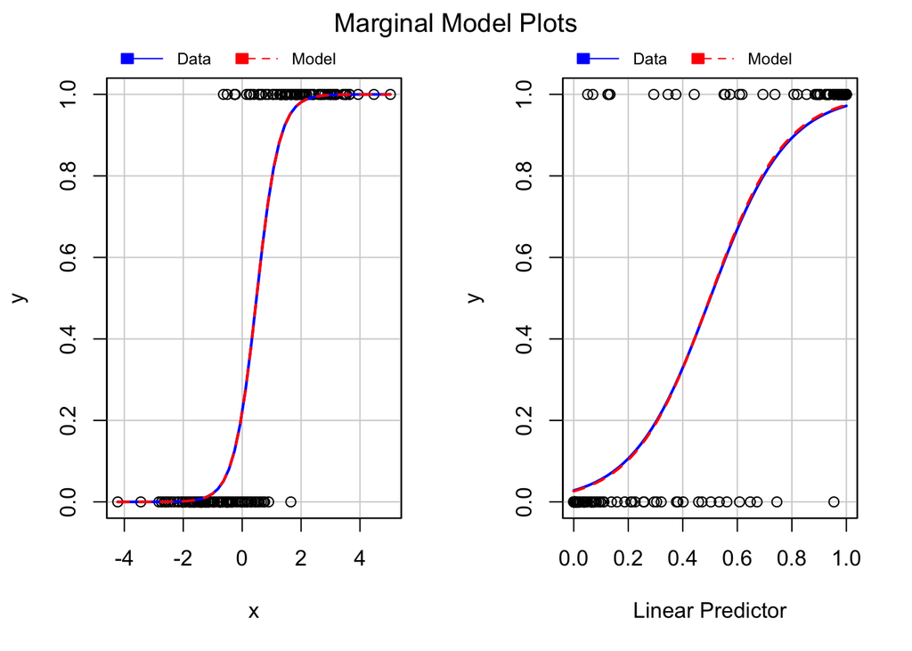

The marginal model plots show good agreement, indicating a great fit.

```r
car::mmps(m1,layout=c(1,2))
```

# Data generation for a Gaussian when beta’s are specified

If you specify the beta’s in the logistic regression, you can check that your code is working by recovering those values.

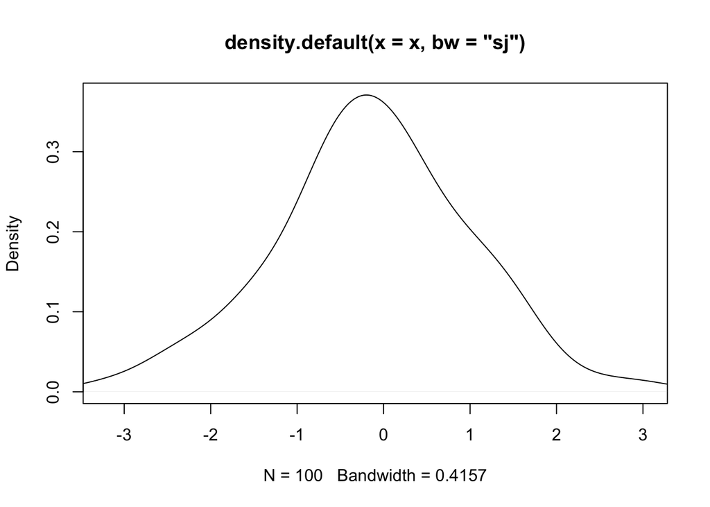

```r
set.seed(44)
n <- 100
beta0 <- 0
beta1 <- 2
## number of successes
x <- rnorm(n = n, mean = 0, sd = 1)
plot(density(x, bw = "sj"), xlim=c(min(x), max(x)))
```

```r
theta_x <- 1/( 1 + exp(-(beta0 + beta1*x)) )
y <- rbinom(n = n, size = 1, prob = theta_x )
x1 <- x[y==1]
x0 <- x[y==0]
mean(x1); sd(x1)
```

```
## [1] 0.52008
```

```
## [1] 0.92335
```

```r
mean(x0); sd(x0)
```

```
## [1] -0.78902
```

```
## [1] 0.92286
```

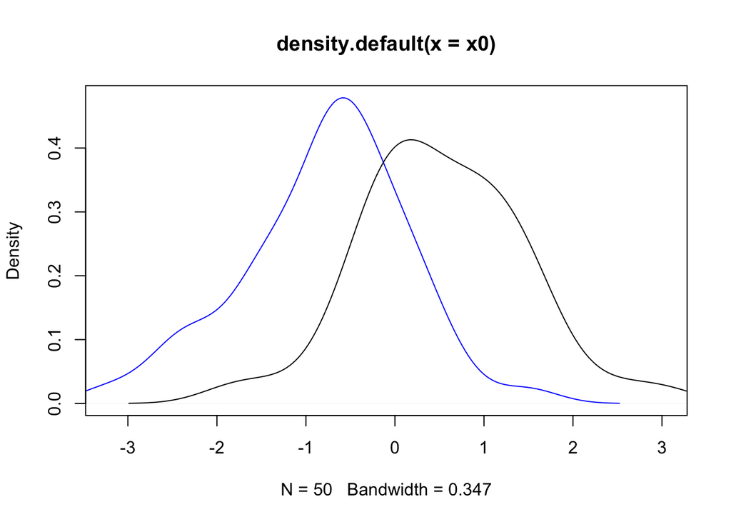

```r
plot(density(x0), xlim=c(min(x0), max(x1)), col = "blue")
lines(density(x1))
```

```r
m1 <- glm( y ~ x, family=binomial() )
summary(m1)
```

```
##
## Call:
## glm(formula = y ~ x, family = binomial())
##
## Deviance Residuals:
##     Min       1Q   Median       3Q      Max
## -2.3827  -0.8075  -0.0025   0.7987   2.4610
##
## Coefficients:
##             Estimate Std. Error z value Pr(>|z|)
## (Intercept)    0.218      0.255    0.86     0.39
## x              1.729      0.367    4.72  2.4e-06
##
## (Dispersion parameter for binomial family taken to be 1)
##
##     Null deviance: 138.629  on 99  degrees of freedom
## Residual deviance:  95.735  on 98  degrees of freedom
## AIC: 99.73
##
## Number of Fisher Scoring iterations: 5
```

Notice that a confidence intervals would cover the true beta’s.

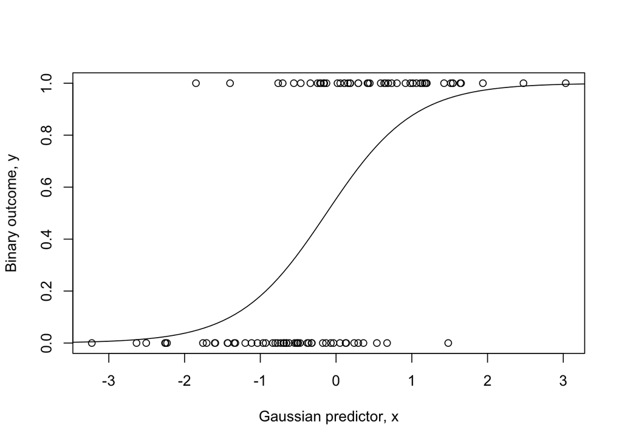

```r
plot(x, y,
     ylab="Binary outcome, y",
     xlab="Gaussian predictor, x")
x_seq <- seq(-4,4,length.out = n )
y_hat <- 1/(1+exp(-1*(m1$coeff[1] + m1$coeff[2]*x_seq)))
lines(x_seq,y_hat)
```

## diagnostics when beta’s are specified

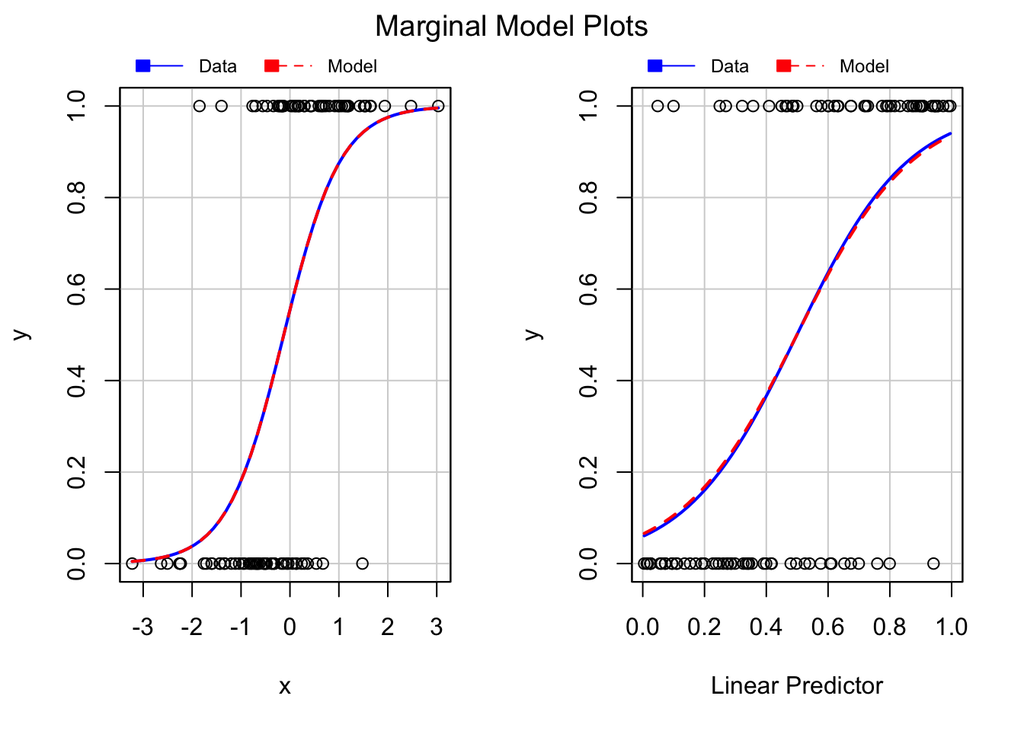

The marginal model plots show good agreement, indicating a great fit.

```r
car::mmps(m1,layout=c(1,2))
```

# Simulting from logistic regression with Gaussian predictor with different variances

## data generation for a Gaussian, different variance

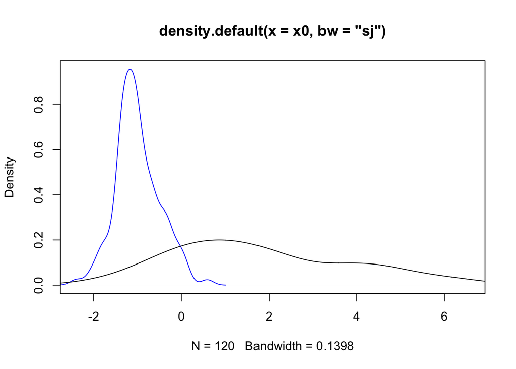

```r
set.seed(444)
n <- 200
## number of successes
theta_overall <- 0.4
## number of successes
num1 <- theta_overall*n
num0 <- n - num1
x1 <- rnorm(n = num1, mean = 2, sd = 2)
x0 <- rnorm(n = num0, mean = -1, sd = 0.5)
plot( density(x0, bw="sj" ), xlim=c(min(x0), max(x1)), col = "blue")
lines( density( x1, bw="sj" ) )
```

```r
x <- c( x1, x0 )
y <- c( rep(1, num1), rep(0, num0) )
m1 <- glm( y ~ x, family=binomial() )
summary(m1)
```

```
##
## Call:
## glm(formula = y ~ x, family = binomial())
##
## Deviance Residuals:
##    Min      1Q  Median      3Q     Max
## -1.912  -0.423  -0.260   0.084   3.229
##
## Coefficients:
##             Estimate Std. Error z value Pr(>|z|)
## (Intercept)    0.154      0.291    0.53      0.6
## x              2.540      0.395    6.43  1.3e-10
##
## (Dispersion parameter for binomial family taken to be 1)
##
##     Null deviance: 269.2  on 199  degrees of freedom
## Residual deviance: 109.4  on 198  degrees of freedom
## AIC: 113.4
##
## Number of Fisher Scoring iterations: 7
```

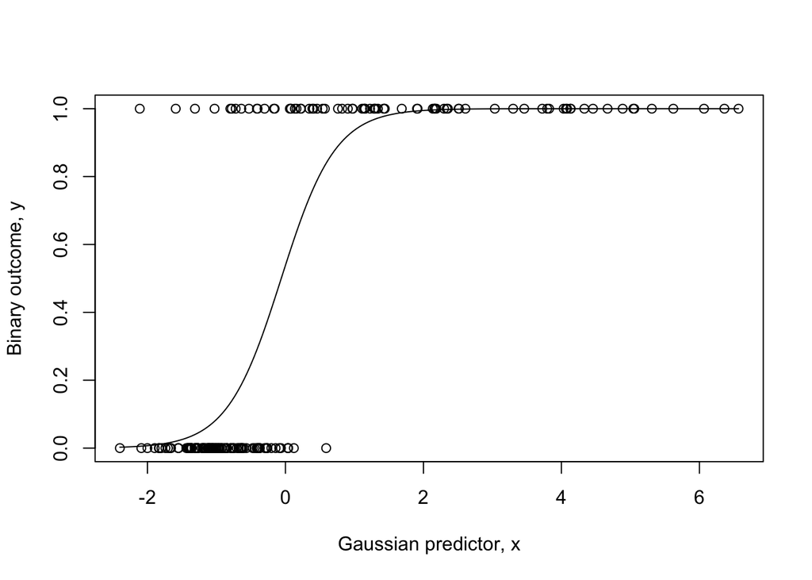

```r
plot(x, y,
     ylab="Binary outcome, y",
     xlab="Gaussian predictor, x")
x_seq <- seq( min(c(x1,x0)), max(c(x1,x0)), length.out = n )
y_hat <- 1/(1+exp(-1*(m1$coeff[1] + m1$coeff[2]*x_seq)))
lines(x_seq,y_hat)
```

## Diagnostics

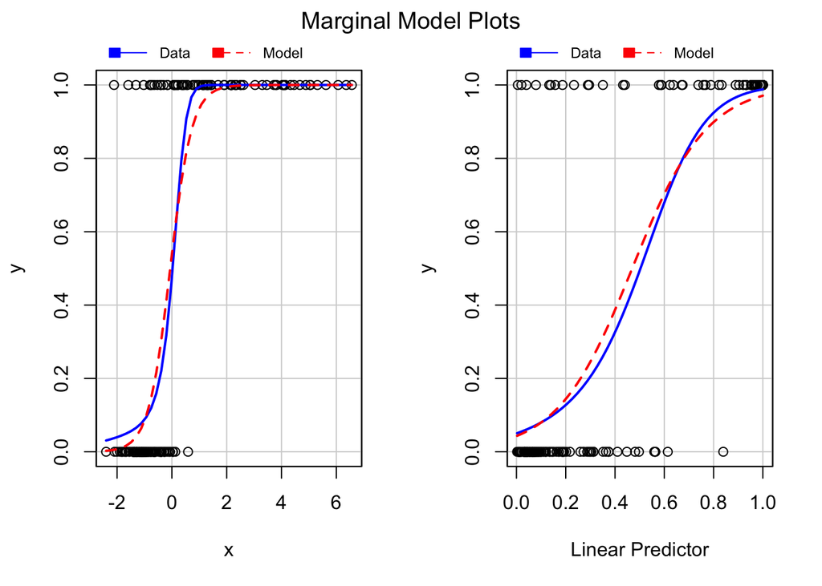

This model is slightly misfit

```r
car::mmps(m1,layout=c(1,2))
```

## Iterate/change model

Following Sheater’s advice Sheather (2009), we’ll include a quadractic term.

```r
m2 <- glm( y ~ x + I(x^2), family=binomial() )
summary(m2)
```

```
##
## Call:
## glm(formula = y ~ x + I(x^2), family = binomial())
##
## Deviance Residuals:
##     Min       1Q   Median       3Q      Max
## -2.4002  -0.3997  -0.3499   0.0008   2.3786
##
## Coefficients:
##             Estimate Std. Error z value Pr(>|z|)
## (Intercept)   0.0111     0.3626    0.03   0.9756
## x             3.9436     0.8523    4.63  3.7e-06
## I(x^2)        1.3913     0.5154    2.70   0.0069
##
## (Dispersion parameter for binomial family taken to be 1)
##
##     Null deviance: 269.20  on 199  degrees of freedom
## Residual deviance: 102.18  on 197  degrees of freedom
## AIC: 108.2
##
## Number of Fisher Scoring iterations: 10
```

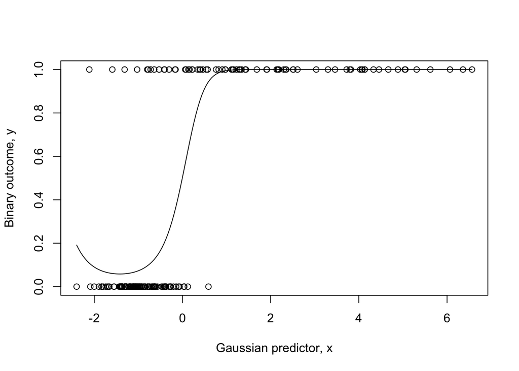

```r
plot(x, y,
     ylab="Binary outcome, y",
     xlab="Gaussian predictor, x")
y_hat <- 1/(1+exp(-1*(m2$coeff[1] + m2$coeff[2]*x_seq + m2$coeff[3]*x_seq^2)))
lines(x_seq,y_hat)
```

## diagnostics

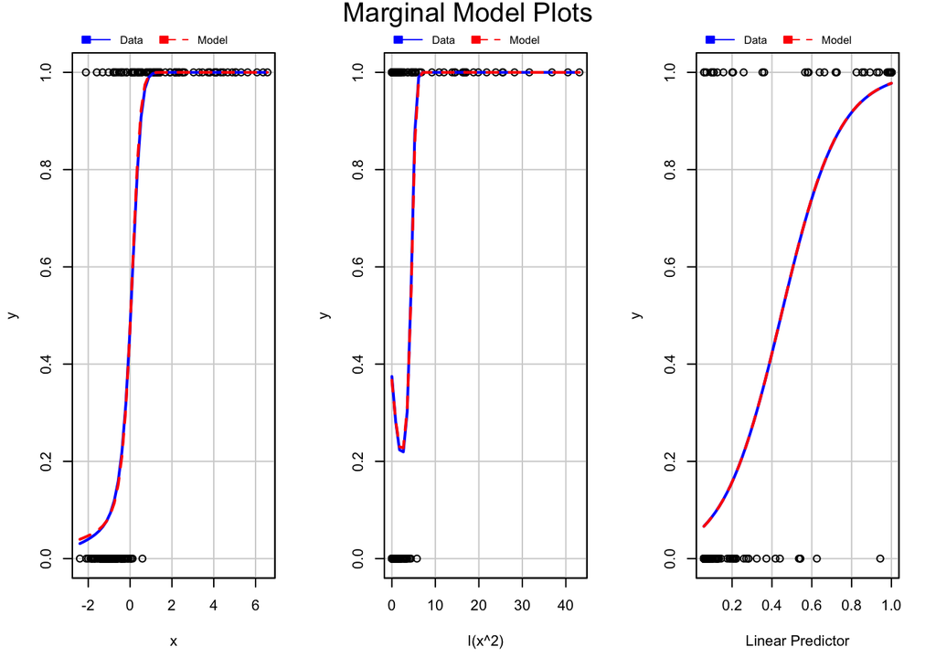

The fit looks great.

```r
car::mmps(m2,layout=c(1,3))
```

# Simulting from logistic regression with Gamma predictor

## data generation for a Gamma predictor

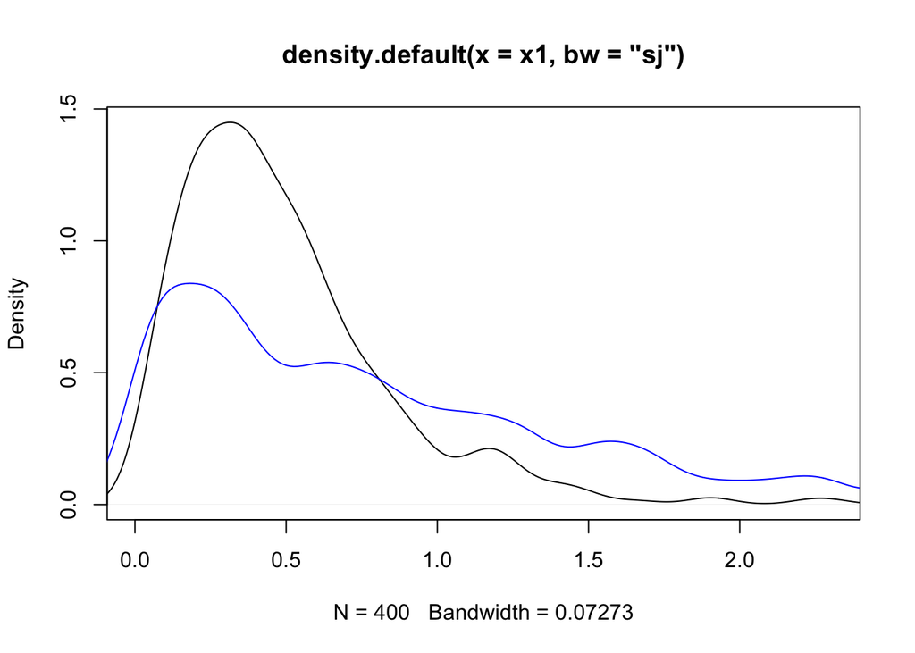

```r
set.seed(4444)
n <- 1000
## number of successes
theta_overall <- 0.4
## number of successes
num1 <- theta_overall*n
num0 <- n - num1
x1 <- rgamma(n = num1, shape = 2, rate = 4)
x0 <- rgamma(n = num0, shape = 1, rate = 1)
plot( density(x1, bw="sj" ), xlim=c(min(x0), max(x1)) )
lines( density( x0, bw="sj" ), col = "blue")
```

```r
x <- c( x1, x0 )
y <- c( rep(1, num1), rep(0, num0) )
m1 <- glm( y ~ x, family=binomial() )
summary(m1)
```

```
##
## Call:
## glm(formula = y ~ x, family = binomial())
##
## Deviance Residuals:
##    Min      1Q  Median      3Q     Max
## -1.336  -1.070  -0.615   1.185   2.179
##
## Coefficients:
##             Estimate Std. Error z value Pr(>|z|)
## (Intercept)    0.366      0.104    3.53  0.00042
## x             -1.146      0.136   -8.46  < 2e-16
##
## (Dispersion parameter for binomial family taken to be 1)
##
##     Null deviance: 1346.0  on 999  degrees of freedom
## Residual deviance: 1238.7  on 998  degrees of freedom
## AIC: 1243
##
## Number of Fisher Scoring iterations: 5
```

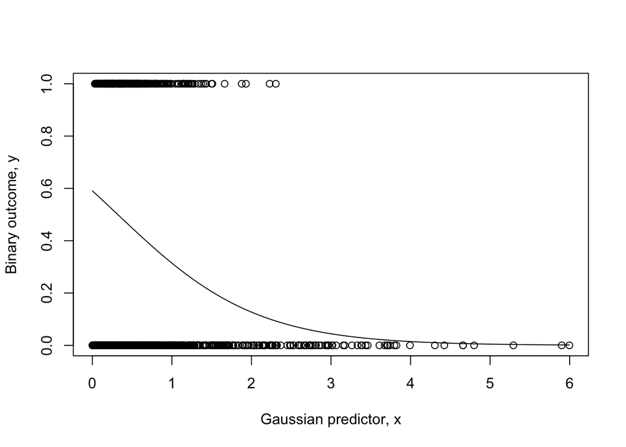

```r
plot(x, y,
     ylab="Binary outcome, y",
     xlab="Gaussian predictor, x")
x_seq <- seq( min(c(x1,x0)), max(c(x1,x0)), length.out = n )
y_hat <- 1/(1+exp(-1*(m1$coeff[1] + m1$coeff[2]*x_seq)))
lines(x_seq,y_hat)
```

## diagnostics

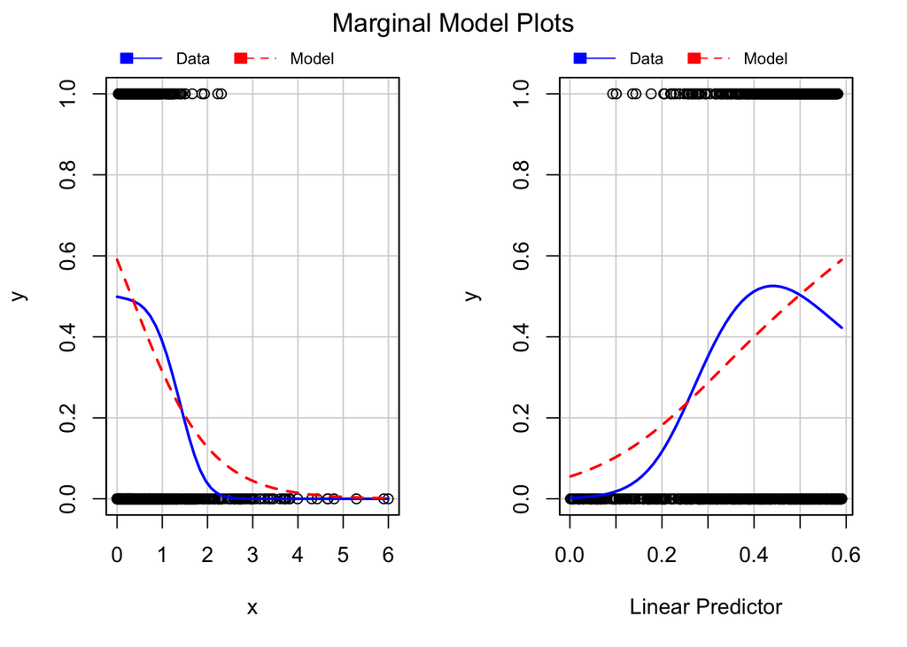

This model is misfit!

```r
car::mmps(m1,layout=c(1,2))
```

## iterate/change model

Following Sheater’s advice Sheather (2009), we’ll include a log(x) term.

```r
m2 <- glm( y ~ x + log(x), family=binomial() )
summary(m2)
```

```
##
## Call:
## glm(formula = y ~ x + log(x), family = binomial())
##
## Deviance Residuals:
##    Min      1Q  Median      3Q     Max
## -1.305  -1.097  -0.396   1.089   2.828
##
## Coefficients:
##             Estimate Std. Error z value Pr(>|z|)
## (Intercept)    2.625      0.349    7.53  5.1e-14
## x             -3.274      0.370   -8.86  < 2e-16
## log(x)         1.129      0.165    6.85  7.3e-12
##
## (Dispersion parameter for binomial family taken to be 1)
##
##     Null deviance: 1346.0  on 999  degrees of freedom
## Residual deviance: 1170.5  on 997  degrees of freedom
## AIC: 1177
##
## Number of Fisher Scoring iterations: 6
```

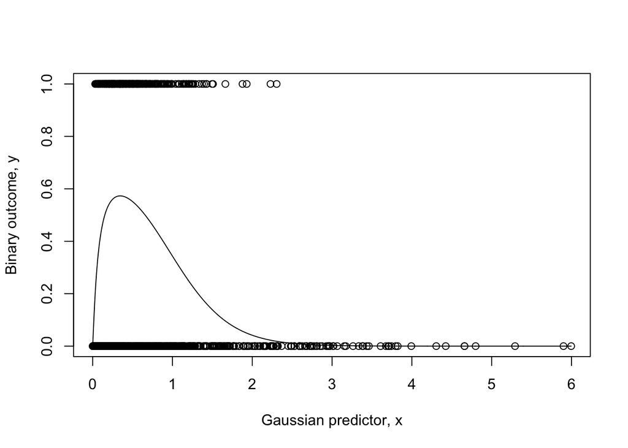

```r
plot(x, y,
     ylab="Binary outcome, y",
     xlab="Gaussian predictor, x")
y_hat <- 1/(1+exp(-1*(m2$coeff[1] + m2$coeff[2]*x_seq + m2$coeff[3]*log(x_seq))))
lines(x_seq,y_hat)
```

## diagnostics

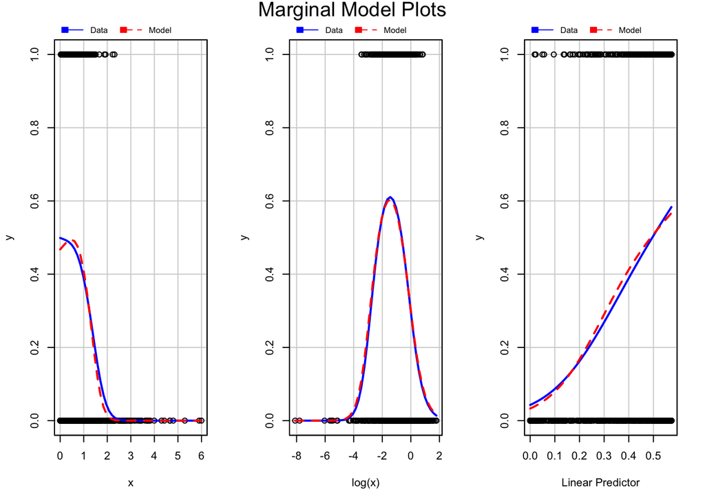

The fit looks much better.

```r
car::mmps(m2,layout=c(1,3))
```

# Conclusion

## Summary

- Simulation is a great tool to understand what your model is doing.
- It also helps to double check your code.
- Also, it will guide model refinement.
- Try Shiny to build interactive plots for a real playground (um, laboratory)

## References

Sheather, Simon. 2009. *A Modern Approach to Regression with R*. Springer Science & Business Media.